# Module 4 - Differences-in-Differences (Answer Key)

ECON 526/593E

# Difference-in-Differences

**Click for Submission Instructions & Data**

Prepare your answers in R Markdown. Your submission should contain the exact same headings shown below along with your text and graphs, where appropriate, addressing all questions. When you knit your R Markdown script, use the following file naming convention for the html and Rmd documents you generate: lastname_module_N_homework.html (.Rmd) (replace "lastname" with your last name and "N" with the module number). Email your documents as attachments to ajc0056@mix.wvu.edu with the subject line "ECON 593 lastname Homework Module N". You can download the data for this module here and here. It will specify when/where packages are needed.

Like the material in Module 4, the Module 4 homework builds on the method covered in Module 3: Panel Data models. Panel data models control for unobservable time-invariant heterogeneity within cross sectional units and unobservable time-varying heterogeneity that affects all cross sectional units in each time period. Controlling for unobservable heterogeneity of these forms represents an important improvement over pooled OLS models.

But Panel Data models likely cannot deliver credible causal estimates because of the assumed presence of important, unobservable time-varying factors within cross sectional units correlated with the treatment variable of interest. Suppose you are interested in the causal impact of county business taxes on the number of businesses in a county, since lower taxes might lead businesses to move to a low tax county or new businesses to start in such a county. You have a panel data set on annual county business tax revenues (the treatment variable) and the number of businesses in the county in each year (the outcome variable). A county fixed effect will control for unobservable county-specific factors that affect the number of businesses but do not change over time like local geography, highways, amenities, the presence of a university, and other time-invariant factors. Year-fixed effects will control for time varying factors affecting the number of businesses in all counties like the business cycle, interest rates, gas prices, and national economic business policies.

But the parameter of interest, the parameter on the county tax revenue variable in a panel data model, will not be credibly causal because of the potential presence of within county factors that vary over time that are also correlated with county tax revenues. Factors like worker productivity, local "attitudes" toward business, and other time-varying local factors unique to each county. Empirical researchers now routinely assume that such factors exist, and they have an important effect on any outcome variable of interest.

Difference-in-Differences (DiD) models exploit some exogenous change in the decision making environment in some, but not all cross sectional units. Suppose the state government decides to designate some subset of counties as "business friendly" locations (treated counties) and undertakes an ad campaign to promote these counties as preferred business locations. This program can be exploited in a difference-in-differences framework that compares outcomes within treated counties before and after the program, and also compare treated counties with control counties after the program.

DiD requires panel data and some exogenous change to the decision making environment affecting a subset of cross sectional units. This happens frequently. This homework focuses on a recent paper exploiting a long ago change (Copyrights and Creativity: Evidence from Italian Opera in the Napoleonic Age by Giorcelli and Moser, *Journal of Political Economy*, 2020). During the Napoleonic Wars in Italy, copyright laws applying to musical compositions changed in parts of Italy conquered by Napoleon. Copyright laws allow popular artists like song writers to monetize their work. Without them, other artists can perform their songs without compensating them. Read the paper before completing this Homework. The paper can be found on eCampus.

**Important Note**: The data analyzed can be downloaded from the journal web site and come directly from this paper. But the results yoiu generate will not exactly match those reported in the paper.

## [Click Here](https://alexcardazzi.github.io/teaching/econ-593e/numeric_did.html) for a simple DiD example.

## Question 1

Summarize the main research question in the paper, the application analyzed, and why the DiD method is appropriate for this research question. (**2 Points**)

## Question 2

Describe the data analyzed, including general structure of the data set, sources, and the nature of the data. Discuss why this data set might be appropriate for DiD. (**2 points**)

Read in `operas_1781_1820.csv` and name it `italy`. Tabulate the variable `copyright` by `state` (hint[^1]). What does this tell you? Tabulate the variable `post1801` by `copyright`. What does this tell you (hint[^2])? Find the average yearly new operas premiered by state (hint[^3]).

```r
library("stargazer")

italy <- read.csv("operas_1781-1820.csv", stringsAsFactors = FALSE)

table(italy$state,
      ifelse(italy$copyright == 0, "Control", "Treatment"))
```

```
##
##                Control Treatment
##   d_modena          40         0
##   d_parma           40         0
##   gd_tuscany        40         0
##   lombardy           0        40
##   papal_state       40         0
##   sardinia          40         0
##   two_sicilies      40         0
##   venetia            0        40
```

```r
table(ifelse(italy$copyright == 1, "Lombardy & Venetia", "Other States"),
      ifelse(italy$post1801 == 1, "Post-1800", "Pre-1800"))
```

```
##
##                      Post-1800 Pre-1800
##   Lombardy & Venetia        40       40
##   Other States             120      120
```

```r
aggregate(italy$operas, list(italy$state), mean)
```

```
##        Group.1     x
## 1     d_modena 1.000
## 2      d_parma 1.025
## 3   gd_tuscany 1.200
## 4     lombardy 3.100
## 5  papal_state 2.275
## 6     sardinia 1.525
## 7 two_sicilies 3.275
## 8      venetia 3.025
```

## Question 3

Describe the important components of DiD. Discuss the assumptions underlying the causal inference method used in the empirical analysis. Include a discussion of threats to validity of the results in terms of causal inference. (**2 points**)

## Question 4

Visualize the data. (**2 points**)

Replicate (the format of) Figure 2 *exactly* using `italy`. Replicate the (different) dashed lines, the axes (titles and size), the legend at the bottom, the labels, and the grid lines on the axes. You will likely need Google for some of this, but it is part of the process. Remember, the data will not replicate exactly, but do the best you can. **Closest graph gets extra credit!**

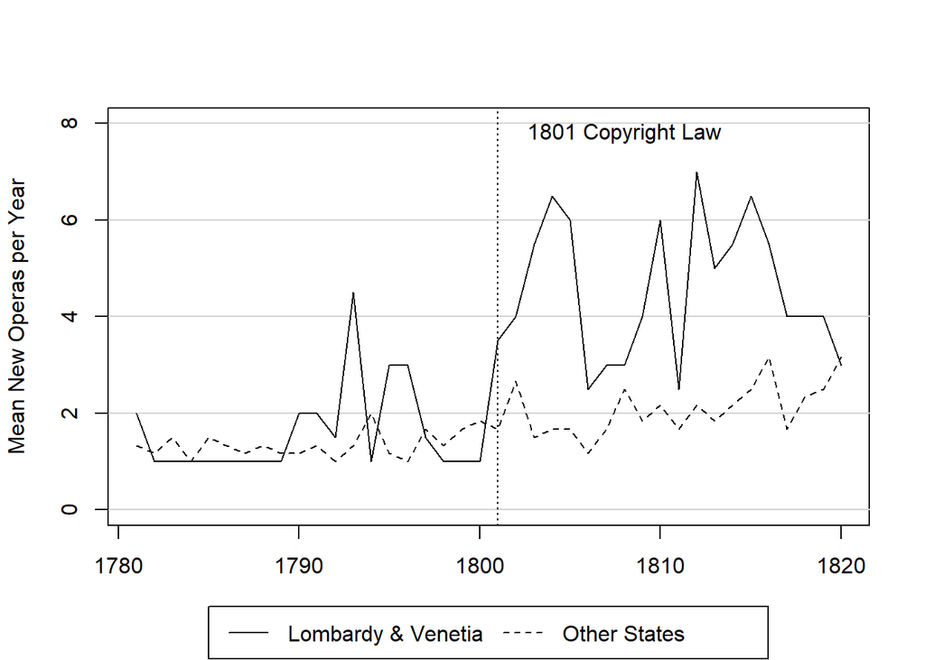

```r
g <- aggregate(italy$operas, list(italy$year, italy$copyright), FUN = mean)
colnames(g) <- c("year", "copyright", "operas")
plot(g$year, g$operas, type = "n",
     ylab = "Mean New Operas per Year", xlab = "", ylim = c(0, 8))
abline(h = c(0, 2, 4, 6, 8), col = "light grey")
lines(g$year[g$copyright == 1], g$operas[g$copyright == 1], type = "l", lty = 1)
lines(g$year[g$copyright == 0], g$operas[g$copyright == 0], type = "l", lty = 2)
abline(v = 1801, lty = 3)

par(xpd=TRUE)
legend(1785,-2,c("Lombardy & Venetia", "Other States"), lty = c(1,2), horiz = TRUE)

par(xpd=FALSE)
text("1801 Copyright Law", x = 1808, y = 7.8)
```

## Question 5

Replicate the main DiD results reported in the paper. Make sure that you follow the guidelines for replicable research in your code. (**2 points**)

Step 1: estimate the DiD coefficient using simple averages in the outcome variable (hint[^4]). Step 2: estimate a simple DiD regression model of the form $Y = \beta_0 + \beta_1 Treat + \beta_2 Post + \delta (Treat * Post) + \epsilon$. Step 3: replicate the results in Column 1 on Table 3 in the paper. Do not worry about replicating the standard errors. Are the results the same as the paper? Are the results the same across both columns? [**ONLY REPLICATE COLUMNS 1 & 2**]

```r
agg <- aggregate(italy$operas, list(italy$copyright, italy$post1801), mean)
colnames(agg) <- c("Copyright", "Post1801", "Mean_Operas")
agg

cat("\nDiD Estimate with Raw Averages: ", (agg$Mean_Operas[4] - agg$Mean_Operas[3]) - (agg$Mean_Operas[2] - agg$Mean_Operas[1]))
```

```
##   Copyright Post1801 Mean_Operas
## 1         0        0    1.350000
## 2         1        0    1.575000
## 3         0        1    2.083333
## 4         1        1    4.550000
##
## DiD Estimate with Raw Averages:  2.241667
```

[output not shown]

[figure not shown]

[figure not shown]

```r
reg0 <- lm(operas ~ post1801*copyright, data = italy)
reg1 <- lm(operas ~ as.factor(year) + as.factor(state) + copyright:post1801 - 1, data = italy)
stargazer(reg0, reg1,
          type = "text",
          omit = c("factor"), omit.stat = c("f", "ser"))
```

```
##
## ===============================================
##                        Dependent variable:
##                    ----------------------------
##                               operas
##                         (1)            (2)
## -----------------------------------------------
## post1801              0.733***
##                       (0.191)
##
## copyright              0.225
##                       (0.270)
##
## post1801:copyright    2.242***
##                       (0.382)
##
## copyright:post1801                  2.242***
##                                      (0.339)
##
## Constant              1.350***
##                       (0.135)
##
## -----------------------------------------------
## Observations            320            320
## R2                     0.315          0.801
## Adjusted R2            0.309          0.766
## ===============================================
## Note:               *p<0.1; **p<0.05; ***p<0.01
```

## Question 6

Discuss the results generated. What is the interpretation of the causal parameter of interest? Place the causal effect in the context of the data. (**2 points**)

Compare the results using simple outcome variable averages to the results using panel data regression models. What, if any, are the reasons for these differences?

## Question 7

Compare your results and this application to the example in *The Mixtape* DiD chapter. Is this application better or worse than the example in the chapter? How does this application, and these results, differ? For example, discuss differences in strength of assumptions, effect size, etc. (**2 points**)

## Question 8

Do you believe the result is credibly causal? Are the sign and magnitude plausible? Why or why not?(**2 points**)

## Extra Credit

Read in `operas_copyright_total.csv` and call it `g1`. These are the data provided by the authors to generate Figure 2. Plot *these* data in an attempt to replicate Figure 2.

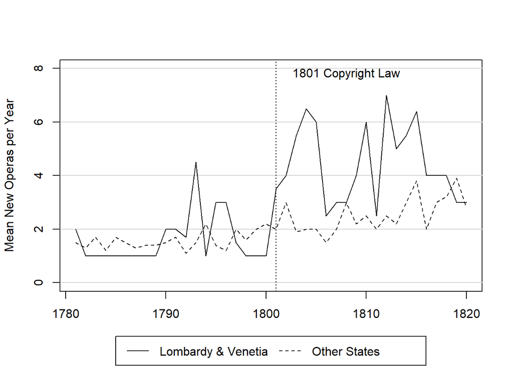

```r
g1 <- read.csv("operas_copyright_total.csv", stringsAsFactors = FALSE)
plot(g1$year, g1$total_operas, type = "n",
     ylab = "Mean New Operas per Year", xlab = "", ylim = c(0, 8))
abline(h = c(0, 2, 4, 6, 8), col = "light grey")
lines(g1$year[g1$copyright == 1], g1$total_operas[g1$copyright == 1], type = "l", lty = 1)
lines(g$year[g1$copyright == 0], g1$total_operas[g1$copyright == 0], type = "l", lty = 2)
abline(v = 1801, lty = 3)

par(xpd=TRUE)
legend(1785,-2,c("Lombardy & Venetia", "Other States"), lty = c(1,2), horiz = TRUE)

par(xpd=FALSE)
text("1801 Copyright Law", x = 1808, y = 7.8)
```

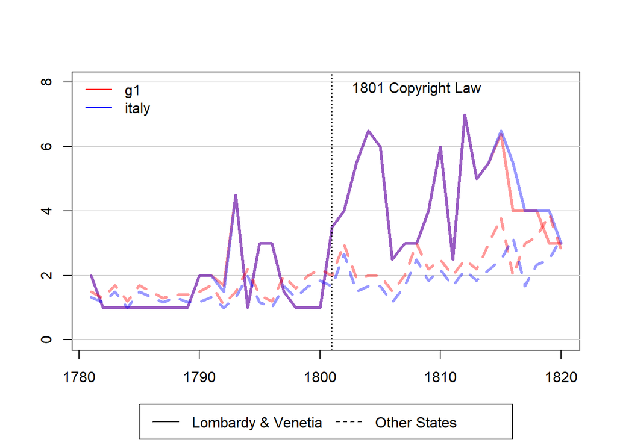

```r
plot(g1$year, g1$total_operas,
     type = "n", ylim = c(0, 8),
     xlab = "", ylab = "")
abline(h = c(0, 2, 4, 6, 8), col = "light grey")
lines(g1$year[g1$copyright == 1], g1$total_operas[g1$copyright == 1],
      col = alpha("red", .4), lwd = 3)
lines(g$year[g$copyright == 1], g$operas[g$copyright == 1],
      col = alpha("blue", .4), lwd = 3)

lines(g1$year[g1$copyright == 0], g1$total_operas[g1$copyright == 0],
      col = alpha("red", .4), lwd = 3, lty = 2)
lines(g$year[g$copyright == 0], g$operas[g$copyright == 0],
      col = alpha("blue", .4), lwd = 3, lty = 2)

abline(v = 1801, lty = 3)

par(xpd=TRUE)
legend(1785,-2,c("Lombardy & Venetia", "Other States"), lty = c(1,2), horiz = TRUE)

par(xpd=FALSE)
text("1801 Copyright Law", x = 1808, y = 7.8)

legend("topleft", legend = c("g1", "italy"),
       col = c("red", "blue"), lty = 1, bty = "n")
```

[^1]: Running the tabulation with the variables will generate a table but the names will be either `1` or `0`. Use the function `ifelse()` to give the variables "names". Denote which group is the treatment and which is the control. For example: `ifelse(x == 4, "x equals 4", "x does not equal 4)`
[^2]: Again, use the function `ifelse()` to give the variables "names".
[^3]: Look into the `aggregate` function. Here is a good resource: [link](https://www.r-bloggers.com/2018/07/how-to-aggregate-data-in-r/)
[^4]: Use the `aggregate` function. The variables you care about are: `copyright`, `post1801` and `operas`.